# SmartEDA

Um pacote R para automatizar a Análise Exploratória de Dados

Sayan Putatunda

Dayananda Ubrangala

Kiran Rama

Ravi Kondapalli

05/01/2023

### Introdução: Análise Exploratória de Dados

Hoje em dia, vemos aplicações de Data Science em quase todos os lugares.  
Alguns dosaspectos mais bem destacados da ciência de dados são as várias técnicas estatísticas e de aprendizado de máquina aplicadas na resolução de problemas.  
No entanto, qualquer atividade de ciência de dados começa com uma **Análise Exploratória de Dados** (EDA - *Exploratory Data Analysis*).  
O termo “Análise Exploratória de Dados” foi criado pelo matemático e estatístico americano, John Tukey (SANDE, 2001). A EDA pode ser definida como *a arte e a ciência de realizar uma investigação inicial sobre os dados* por meio de técnicas estatísticas e de visualizações que possam trazer à tona os aspectos importantes nos dados e que podem ser utilizados posteriormente no processo de análise (Tukey, 1977).  
Na literatura estatística existem muitos estudos sobre EDA. Alguns dos primeiros trabalhos realizados em Análise Exploratória de Dados (AED), incluindo susa definição e o estabelecimento das técnicas básicas em AED foram mostrados em Tukey (1977).  
No entanto, muitos pesquisadores formularam diferentes definições de AED ao longo dos anos.  
Chon Ho (2010) introduziu a AED no contexto de mineração de dados e da reamostragem com foco no reconhecimento de padrões, detecção de agrupamentos (cluster) e na seleção de variáveis.  
Ao longo dos anos, a AED tem sido utilizada em diversos tipos de aplicações e em diferentes domínios, tais como: pesquisa em geociências (Ma et al., 2017), avaliações baseadas em jogos (DiCerbo et al., 2015), grupos de estudos clínicos (Konopka et al., 2018), dentre outros.  
A AED pode ser categorizada em **técnicas estatísticas descritivas** e **técnicas gráficas**. A primeira categoria abrange várias técnicas estatísticas univariadas e multivariadas, enquanto a segunda categoria compreende várias técnicas de visualização. Ambas as técnicas são usadas para explorar e entender os padrões dos dados, compreender as relações existentes entre as variáveis e, o mais importante, gerar **insights** orientados por dados que podem ser usados pelas partes interessadas (stakeholders) nos negócios. No entanto, a AED requer muito esforço manual e também uma quantidade substancial de esforço de codificação em um ambiente de programação como o R (R Core Team, 2017). Existe uma grande necessidade de automação do processo EDA, e isso nos motivou a desenvolver o pacote **SmartEDA** e elaborar este artigo.

### Principal Funcionalidade

O pacote SmartEDA seleciona automaticamente as variáveis e executa as funções estatisticas descritivas afins.  
Além disso, também analisa o valor da informação, o peso da evidência, tabelas personalizadas, estatísticas resumidas e executa técnicas gráficas tanto para dados numéricos quanto categóricos.  
Algumas das vantagens mais importantes do pacote SmartEDA são que ele pode ajudar na aplicação de ponta a ponta do processo EDA sem ter que lembrar os diferentes nomes de pacotes em R, escrever longos scripts em R, e nenhum esforço manual é necessário para preparar o relatório EDA e, finalmente, automaticamente categorizar as variáveis no tipo de dados correto (ou seja, caractere, numérico, Fator e mais) com base nos dados de entrada.  
Assim, os principais benefícios do SmartEDA estão na economia de tempo de desenvolvimento, menor percentual de erros e reprodutibilidade. Além disso, o pacote SmartEDA possui opções personalizadas para os dados. Pacote de tabelas como:  
(1) Gera estatísticas de resumo apropriadas dependendo do tipo de dados;  
(2) Remodelagem de dados usando data.table.dcast();  
(3) Filtra linhas/casos em que as condições são verdadeiras. Opções para aplicar filtros em nível de variável ou conjunto de dados completo como subconjunto de base; e  
(4) Opções para calcular medidas de tendência central (como Média, Mediana, Moda, etc.), medidas de variância/dispersão (como Desvio Padrão, Variância, etc.), Número de observações, Proporções, Quantis, IQR, Porcentagem de Ações (PS) para dados numéricos.  
A Figura 1 resume as várias funcionalidades do pacote SmartEDA.

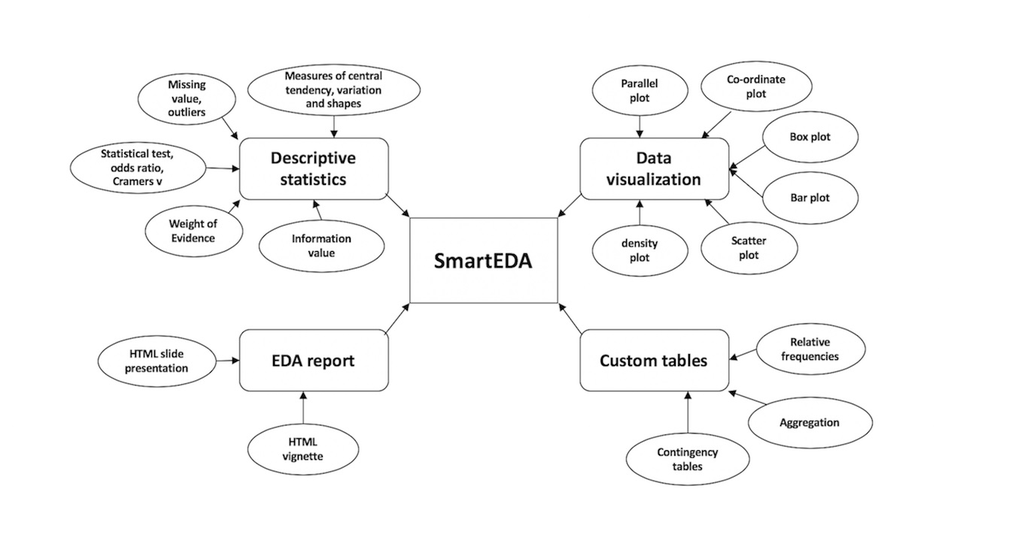

Figura 1: As diversas funcionalidades do SmartEDA.

### Ilustração

Inicialmente, iremos carregar as bibliotecas SmartEDA e ISLR.

```r
#if(!SmartEDA %in% installed.packages()) install.packages("SmartEDA")
library(SmartEDA)
#if(!ISLR %in% installed.packages()) install.packages("ISLR")
library("ISLR")
```

Agora usaremos o SmartEDA para compreender: as dimensões do conjunto de dados, os nomes e tipos de dados de cada variável e observar um resumo geral de dados ausentes (missing data) .

```r
Carseats <- ISLR::Carseats
ExpData(data=Carseats,type=1)
```

| Descriptions | Value |
| --- | --- |
| Sample size (nrow) | 400 |
| No. of variables (ncol) | 11 |
| No. of numeric/interger variables | 8 |
| No. of factor variables | 3 |
| No. of text variables | 0 |
| No. of logical variables | 0 |
| No. of identifier variables | 0 |
| No. of date variables | 0 |
| No. of zero variance variables (uniform) | 0 |
| %. of variables having complete cases | 100% (11) |

[output cut: 3 more lines]

```r
# saída
```

Agora, vejamos o resumo das variáveis numéricas/inteiras, como Advertising, Age,CompPrice, Income, Population, Price e Sales.

```r
ExpNumStat(Carseats,by="A",gp=NULL,Qnt=NULL,MesofShape=2, Outlier=FALSE,round=2,Nlim=10)
```

|  | Vname | Group | TN | nNeg | nZero | nPos | NegInf | PosInf | NA_Value | Per_of_Missing | sum | min | max | mean | median | SD | CV | IQR | Skewness | Kurtosis |
| --- | --- | --- | --- | --- | --- | --- | --- | --- | --- | --- | --- | --- | --- | --- | --- | --- | --- | --- | --- | --- |
| 4 | Advertising | All | 400 | 0 | 144 | 256 | 0 | 0 | 0 | 0 | 2654.00 | 0 | 29.00 | 6.64 | 5.00 | 6.65 | 1.00 | 12.00 | 0.64 | -0.55 |
| 7 | Age | All | 400 | 0 | 0 | 400 | 0 | 0 | 0 | 0 | 21329.00 | 25 | 80.00 | 53.32 | 54.50 | 16.20 | 0.30 | 26.25 | -0.08 | -1.14 |
| 2 | CompPrice | All | 400 | 0 | 0 | 400 | 0 | 0 | 0 | 0 | 49990.00 | 77 | 175.00 | 124.97 | 125.00 | 15.33 | 0.12 | 20.00 | -0.04 | 0.03 |
| 3 | Income | All | 400 | 0 | 0 | 400 | 0 | 0 | 0 | 0 | 27463.00 | 21 | 120.00 | 68.66 | 69.00 | 27.99 | 0.41 | 48.25 | 0.05 | -1.09 |
| 5 | Population | All | 400 | 0 | 0 | 400 | 0 | 0 | 0 | 0 | 105936.00 | 10 | 509.00 | 264.84 | 272.00 | 147.38 | 0.56 | 259.50 | -0.05 | -1.20 |
| 6 | Price | All | 400 | 0 | 0 | 400 | 0 | 0 | 0 | 0 | 46318.00 | 24 | 191.00 | 115.80 | 117.00 | 23.68 | 0.20 | 31.00 | -0.12 | 0.43 |
| 1 | Sales | All | 400 | 0 | 1 | 399 | 0 | 0 | 0 | 0 | 2998.53 | 0 | 16.27 | 7.50 | 7.49 | 2.82 | 0.38 | 3.93 | 0.18 | -0.10 |

```r
#Saída- Resumo das variáveis numéricas dos dados Carseats
```

Vamos agora verificar o resumo das variáveis categóricas, ou seja, ShelveLoc, Urban e US.

```r
ExpCTable(Carseats)
```

| Variable | Valid | Frequency | Percent | CumPercent |
| --- | --- | --- | --- | --- |
| ShelveLoc | Bad | 96 | 24.00 | 24.00 |
| ShelveLoc | Good | 85 | 21.25 | 45.25 |
| ShelveLoc | Medium | 219 | 54.75 | 100.00 |
| ShelveLoc | TOTAL | 400 | NA | NA |
| Urban | No | 118 | 29.50 | 29.50 |
| Urban | Yes | 282 | 70.50 | 100.00 |
| Urban | TOTAL | 400 | NA | NA |
| US | No | 142 | 35.50 | 35.50 |
| US | Yes | 258 | 64.50 | 100.00 |
| US | TOTAL | 400 | NA | NA |

[output cut: 10 more lines]

```r
#Output- Resumo das variáveis categóricas dos dados Carseats
```

### Comparação com outros pacotes R

A Figura 3 compara o pacote SmartEDA (Ubrangala, Rama, Kondapalli, & Putatunda, 2018) com outros pacotes semelhantes disponíveis no CRAN para análise exploratória de dados viz. dlookr (Ryu, 2018), DataExplorer (Cui, 2018), Hmisc (Harrell et al., 2018), exploreR (Coates, 2016), Tutor (Nair, 2018) e summarytools (Comtois, 2018).  
A métrica para avaliação é a disponibilidade de vários recursos desejados para realizar uma análise exploratória de dados, tais como:  
(a) Descrever informações básicas para dados de entrada;  
(b) Função a fornecer;  
(c) estatísticas resumidas para todas as variáveis numéricas;  
(d) Função para fornecer gráficos para todas as variáveis numéricas;  
(e) Função para fornecer estatísticas de resumo para todos os caracteres ou variáveis categóricas;  
(f) Função para fornecer gráficos para todos os caracteres ou variáveis categóricas;  
(g) Estatísticas de resumo personalizadas - extensão para dados. Pacote data.table;  
(h) Gráficos de normalidade/coordenadas;  
(i) Binarização/binning de recursos;  
(j) Padronizar/faltar imputação/diagnosticar outliers; e  
(k) Relatório HTML usando rmarkdown/Shiny.

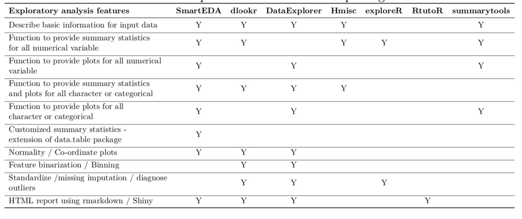

[Figura 3 - ]  
Figura 3: Comparação do SmartEDA com os pacotes R disponíveis.

### Disponibilidade

O software é distribuído sob uma LICENÇA de arquivo MIT + (Repositório: CRAN) e está disponível em https://github.com/daya6489/SmartEDA.

### Reconhecimentos

Queremos agradecer à VMware e à liderança do Enterprise and Data Analytics (EDA) por nos fornecer a infraestrutura e o suporte necessários para este trabalho. Somos gratos à comunidade R por sua aceitação e feedback para melhorar ainda mais nosso pacote.

### Referências Bibliográficas

Chon Ho, Y. (2010). Exploratory data analysis in the context of data mining and resampling. International Journal of Psychological Research, 3(1), 9–22. doi:https://doi.org/10.21500/ 20112084.819  
Coates, M. (2016). exploreR: Tools for Quickly Exploring Data. Retrieved from {https://CRAN.R-project.org/package=exploreR}  
Comtois, D. (2018). summarytools: Tools to Quickly and Neatly Summarize Data. Retrieved from {https://CRAN.R-project.org/package=summarytools}  
Cui, B. (2018). DataExplorer: Data Explorer. Retrieved from {https://CRAN.Rproject. org/package=DataExplorer}  
DiCerbo et al. (2015). Serious Games Analytics. Advances in Game-Based Learning. In C. Loh, Y. Sheng, & D. Ifenthaler (Eds.),. Cham: Springer. doi:10.1007/978-3-319-05834-4 Harrell et al. (2018). Hmisc: Harrell Miscellaneous. Retrieved from {https://CRAN.Rproject. org/package=Hmisc}  
James, G., Witten, D., Hastie, T., & Tibshirani, R. (2017). ISLR: Data for an Introduction to Statistical Learning with Applications in R. doi:https://doi.org/10.1007/ 978-1-4614-7138-7_1  
Konopka et al. (2018). Exploratory data analysis of a clinical study group: Development of a procedure for exploring multidimensional data. PLoS ONE, 13(8). doi:https://doi.org/10. 1371/journal.pone.0201950  
Ma, X., Hummer, D., Golden, J. J., Fox, P. A., Hazen, R. M., Morrison, S. M., Downs, R. T., et al. (2017). Using Visual Exploratory Data Analysis to Facilitate Collaboration and Hypothesis Generation in Cross-Disciplinary Research. International Journal of Geo-Information, 6(368), 1–11. doi:https://doi.org/10.3390/ijgi6110368  
Nair, A. (2018). RtutoR: Shiny Apps for Plotting and Exploratory Analysis. Retrieved from {https://CRAN.R-project.org/package=RtutoR}  
R Core Team. (2017). R: A Language and Environment for Statistical Computing. Vienna, Austria: R Foundation for Statistical Computing. Retrieved from https://www.R-project.org/ Ryu, C. (2018). dlookr: Tools for Data Diagnosis, Exploration, Transformation. Retrieved from {https://CRAN.R-project.org/package=dlookr}  
Sande, Gordon (July 2001). “Obituary: John Wilder Tukey”. Physics Today. 54 (7): 80–81. doi:10.1063/1.1397408.  
Tukey, J. W. (1977). Exploratory data analysis. Addison-Wesley.  
Ubrangala, D., Rama, K., Kondapalli, R. P., & Putatunda, S. (2018). SmartEDA: Summarize and Explore the Data. Retrieved from {https://CRAN.R-project.org/package=SmartEDA}